# Practical Machine Learning Course Project

Ivan Lozo

15 svibnja 2017

### Introduction

This is an Markdown document created with purpose to present results of predictive analyses on people personal activity. It is created as result of Practical Machine Learning Course Project. Data is provided by http://groupware.les.inf.puc-rio.br/har. Purpose of the modelling is to predict the manner in which people did the exercise which is part of the “classe” variable in the training set.

### Importing data

For importing data we will use Hedley’s readr package.

```r
library(readr)

training <- read_csv("~/R/PracticalMachineLearning1/pml-training.csv",
col_types = cols(kurtosis_picth_arm = col_double(),
       kurtosis_picth_belt = col_double(),
       kurtosis_yaw_arm = col_double(),
       kurtosis_yaw_belt = col_double(),
       kurtosis_yaw_dumbbell = col_double(),
        kurtosis_yaw_forearm = col_double(),
        skewness_pitch_arm = col_double(),
        skewness_roll_belt.1 = col_double(),
        skewness_yaw_arm = col_double(),
        skewness_yaw_belt = col_double(),
       skewness_yaw_dumbbell = col_double(),
       skewness_yaw_forearm = col_double()))


testing <- read.csv("pml-testing.csv")
```

### Data inspection

Let’s examine training data set that we will use for modelling.

Training dataset contains 19 622 rows and 160 columns

```r
dim(training)
```

```
## [1] 19622   160
```

```r
head(training,n = 20)
```

```
## # A tibble: 20 × 160
##       X1 user_name raw_timestamp_part_1 raw_timestamp_part_2
##    <int>     <chr>                <int>                <int>
## 1      1  carlitos           1323084231               788290
## 2      2  carlitos           1323084231               808298
## 3      3  carlitos           1323084231               820366
## 4      4  carlitos           1323084232               120339
## 5      5  carlitos           1323084232               196328
## 6      6  carlitos           1323084232               304277
## 7      7  carlitos           1323084232               368296
## 8      8  carlitos           1323084232               440390
## 9      9  carlitos           1323084232               484323
## 10    10  carlitos           1323084232               484434
## 11    11  carlitos           1323084232               500302
## 12    12  carlitos           1323084232               528316
## 13    13  carlitos           1323084232               560359
## 14    14  carlitos           1323084232               576390
## 15    15  carlitos           1323084232               604281
## 16    16  carlitos           1323084232               644302
## 17    17  carlitos           1323084232               692324
## 18    18  carlitos           1323084232               732306
## 19    19  carlitos           1323084232               740353
## 20    20  carlitos           1323084232               788335
## # ... with 156 more variables: cvtd_timestamp <chr>, new_window <chr>,
## #   num_window <int>, roll_belt <dbl>, pitch_belt <dbl>, yaw_belt <dbl>,
## #   total_accel_belt <int>, kurtosis_roll_belt <dbl>,
## #   kurtosis_picth_belt <dbl>, kurtosis_yaw_belt <dbl>,
## #   skewness_roll_belt <dbl>, skewness_roll_belt.1 <dbl>,
## #   skewness_yaw_belt <dbl>, max_roll_belt <dbl>, max_picth_belt <int>,
## #   max_yaw_belt <dbl>, min_roll_belt <dbl>, min_pitch_belt <int>,
## #   min_yaw_belt <dbl>, amplitude_roll_belt <dbl>,
## #   amplitude_pitch_belt <int>, amplitude_yaw_belt <dbl>,
## #   var_total_accel_belt <dbl>, avg_roll_belt <dbl>,
## #   stddev_roll_belt <dbl>, var_roll_belt <dbl>, avg_pitch_belt <dbl>,
## #   stddev_pitch_belt <dbl>, var_pitch_belt <dbl>, avg_yaw_belt <dbl>,
## #   stddev_yaw_belt <dbl>, var_yaw_belt <dbl>, gyros_belt_x <dbl>,
## #   gyros_belt_y <dbl>, gyros_belt_z <dbl>, accel_belt_x <int>,
## #   accel_belt_y <int>, accel_belt_z <int>, magnet_belt_x <int>,
## #   magnet_belt_y <int>, magnet_belt_z <int>, roll_arm <dbl>,
## #   pitch_arm <dbl>, yaw_arm <dbl>, total_accel_arm <int>,
## #   var_accel_arm <dbl>, avg_roll_arm <dbl>, stddev_roll_arm <dbl>,
## #   var_roll_arm <dbl>, avg_pitch_arm <dbl>, stddev_pitch_arm <dbl>,
## #   var_pitch_arm <dbl>, avg_yaw_arm <dbl>, stddev_yaw_arm <dbl>,
## #   var_yaw_arm <dbl>, gyros_arm_x <dbl>, gyros_arm_y <dbl>,
## #   gyros_arm_z <dbl>, accel_arm_x <int>, accel_arm_y <int>,
## #   accel_arm_z <int>, magnet_arm_x <int>, magnet_arm_y <int>,
## #   magnet_arm_z <int>, kurtosis_roll_arm <dbl>, kurtosis_picth_arm <dbl>,
## #   kurtosis_yaw_arm <dbl>, skewness_roll_arm <dbl>,
## #   skewness_pitch_arm <dbl>, skewness_yaw_arm <dbl>, max_roll_arm <dbl>,
## #   max_picth_arm <dbl>, max_yaw_arm <int>, min_roll_arm <dbl>,
## #   min_pitch_arm <dbl>, min_yaw_arm <int>, amplitude_roll_arm <dbl>,
## #   amplitude_pitch_arm <dbl>, amplitude_yaw_arm <int>,
## #   roll_dumbbell <dbl>, pitch_dumbbell <dbl>, yaw_dumbbell <dbl>,
## #   kurtosis_roll_dumbbell <dbl>, kurtosis_picth_dumbbell <dbl>,
## #   kurtosis_yaw_dumbbell <dbl>, skewness_roll_dumbbell <dbl>,
## #   skewness_pitch_dumbbell <dbl>, skewness_yaw_dumbbell <dbl>,
## #   max_roll_dumbbell <dbl>, max_picth_dumbbell <dbl>,
## #   max_yaw_dumbbell <dbl>, min_roll_dumbbell <dbl>,
## #   min_pitch_dumbbell <dbl>, min_yaw_dumbbell <dbl>,
## #   amplitude_roll_dumbbell <dbl>, amplitude_pitch_dumbbell <dbl>,
## #   amplitude_yaw_dumbbell <dbl>, total_accel_dumbbell <int>,
## #   var_accel_dumbbell <dbl>, avg_roll_dumbbell <dbl>, ...
```

Let’s look at the distribution of target variable.

```r
table(training$classe)
```

```
##
##    A    B    C    D    E
## 5580 3797 3422 3216 3607
```

### Data cleaning

First, we will remove also first 6 columns, since they don’t contain usefull data.

```r
training <- training[, -(1:6)]
testing <- testing[, -(1:6)]
```

Then, we will remove columns with all missing variables.

```r
allmisscols <- apply(training,2, function(x)all(is.na(x)))
colswithallmiss <-names(allmisscols[allmisscols>0])

training <- training[, -which(names(training)%in%colswithallmiss)]
testing <- testing[, -which(names(testing)%in%colswithallmiss)]
```

```r
training <- training[,colMeans(is.na(training))<0.10]
testing <- testing[,colMeans(is.na(testing))<0.10]
```

```r
training[] <- lapply(training,function(x) ifelse(is.na(x), mean(x,na.rm = T),x))
```

Now that we have clean data with missing values, we will examine corellation range between variables.

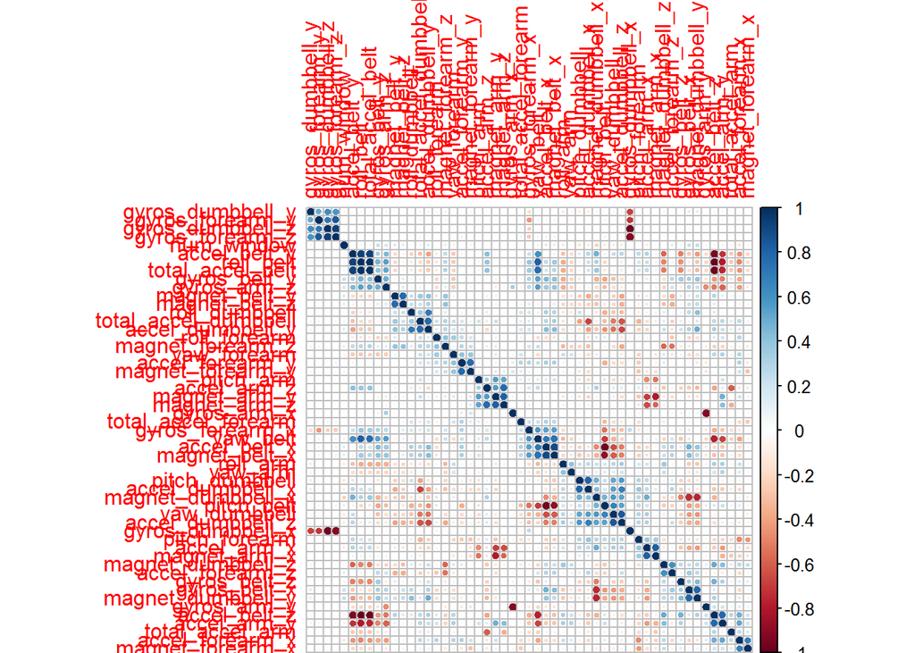

```r
library(corrplot)

trainingCor <- cor(training[,-54])
corrplot(trainingCor,order = "hclust")
```

Finally, we will remove variables correlated more than 80%.

```r
library(caret)
highlyCorr <- findCorrelation(trainingCor,cutoff = 0.80)

training <- training[,-c(highlyCorr)]
testing <- testing[,-highlyCorr]
```

After cleaning data and removing highly corellated variables we have dataset of 40 predictors left on which we will train gbm algorithm.

```r
dim(training)
```

```
## [1] 19622    41
```

### Modelling

Now, we will fit gbm model from caret package in order to build a model for prediction of classe variable. First, we will transform target variable to factor, then divide dataset to train (75%) and validation (25%). Next, we will transform predictors using scale and center mehods

```r
training$classe <- factor(training$classe)
set.seed(1)
trainID <- createDataPartition(training$classe,p = 0.75, list=FALSE)

train <- training[trainID,]
validation <- training[-trainID,]

#remove original training dataset
rm(training)

trainPreProcess <- preProcess(x = train[,-41], method = c("center","scale"))

trainTransform <- predict(trainPreProcess,train)

#remove original training
rm(train)
```

We will use crossvalidation resampling with 5 folds in order to decrease computation time.

Fit the gbm model.

```r
trainCntr <- trainControl(method = "cv",number = 5)
gbm <- train(classe~.,data = trainTransform, method="gbm",verbose = FALSE,trControl = trainCntr)
```

Now, we will transform validation set and make prediction in order to calculate accuracy and out of sample error.

```r
validTransform <- predict(trainPreProcess,validation)
valPred <- predict(gbm,validTransform)

accuracy <- sum(valPred==validTransform$classe) / length(valPred)
outError <- 1 - accuracy
confusionMatrix(valPred,validTransform$classe)
```

```
## Confusion Matrix and Statistics
##
##           Reference
## Prediction    A    B    C    D    E
##          A 1394    4    0    0    0
##          B    1  937    4    0    2
##          C    0    8  849    9    1
##          D    0    0    2  792   12
##          E    0    0    0    3  886
##
## Overall Statistics
##
##                Accuracy : 0.9906
##                  95% CI : (0.9875, 0.9931)
##     No Information Rate : 0.2845
##     P-Value [Acc > NIR] : < 2.2e-16
##
##                   Kappa : 0.9881
##  Mcnemar's Test P-Value : NA
##
## Statistics by Class:
##
##                      Class: A Class: B Class: C Class: D Class: E
## Sensitivity            0.9993   0.9874   0.9930   0.9851   0.9834
## Specificity            0.9989   0.9982   0.9956   0.9966   0.9993
## Pos Pred Value         0.9971   0.9926   0.9792   0.9826   0.9966
## Neg Pred Value         0.9997   0.9970   0.9985   0.9971   0.9963
## Prevalence             0.2845   0.1935   0.1743   0.1639   0.1837
## Detection Rate         0.2843   0.1911   0.1731   0.1615   0.1807
## Detection Prevalence   0.2851   0.1925   0.1768   0.1644   0.1813
## Balanced Accuracy      0.9991   0.9928   0.9943   0.9908   0.9913
```

Accuracy on the validation data is 0.99, which means that out of sample error is 0.01

Finally, we will transform test dataset and make prediction for the final submission.

```r
testTransform <- predict(trainPreProcess,testing)
testPred <- predict(gbm,testTransform)
testPred
```

```
##  [1] B A B A A E D B A A B C B A E E A B B B
## Levels: A B C D E
```